# Normalidade dos resíduos: exemplo prático

Diagnóstico visual, teste de Shapiro-Wilk e transformação logarítmica

Author

Ana Matiussi, Paula Cardoso e Thiago Ludwig

Published

05/05/2026

Este relatório apresenta um **exemplo didático** sobre a avaliação da **normalidade dos resíduos** em modelos lineares.

A ideia central é mostrar que a normalidade não deve ser avaliada apenas nos dados brutos, mas principalmente nos **resíduos do modelo**. Para isso, foi usado dois conjuntos de dados disponíveis no R:

- `mtcars`: exemplo em que os resíduos apresentam comportamento aproximadamente normal;
- `airquality`: exemplo com assimetria, valores extremos e melhoria após transformação logarítmica.

**O diagnóstico foi feito combinando:**

- Histograma dos resíduos;
- QQ-plot;
- Teste de Shapiro-Wilk;
- Interpretação estatística.

## Ato 1 - Exemplo em que a normalidade funciona bem

Neste primeiro exemplo, foi usado o banco de dados `mtcars` e ajustado um **modelo linear simples**, sendo:

$$y_i = \beta_0 + \beta_1 x_i + \varepsilon_i \quad ,\quad \varepsilon_i = y_i - \widehat{y}_i$$

O objetivo é explicar o consumo de combustível (`mpg`) a partir do peso do carro (`wt`). Como mpg mede milhas por galão, valores maiores indicam melhor eficiência. Então a tendência esperada é: quanto maior o peso, menor o mpg.

Portanto, temos o seguinte modelo:

$$mpg_i = \beta_0 + \beta_1 wt_i + \varepsilon_i$$

Após o ajuste, avaliamos se os resíduos apresentam comportamento aproximadamente normal.

```r
# Ajustando o modelo
modelo1 = lm(mpg ~ wt, data = mtcars)

# Extrair os resíduos de um modelo ajustado
res1 = residuals(modelo1)

# Coeficientes da regressão linear (intercepto e inclinação)
modelo1$coefficients
```

```
(Intercept)          wt
  37.285126   -5.344472
```

```r
# Detalhes estatísticos
summary(modelo1)
```

```
Call:
lm(formula = mpg ~ wt, data = mtcars)

Residuals:
    Min      1Q  Median      3Q     Max
-4.5432 -2.3647 -0.1252  1.4096  6.8727

Coefficients:
            Estimate Std. Error t value Pr(>|t|)
(Intercept)  37.2851     1.8776  19.858  < 2e-16 ***
wt           -5.3445     0.5591  -9.559 1.29e-10 ***
---
Signif. codes:  0 '***' 0.001 '**' 0.01 '*' 0.05 '.' 0.1 ' ' 1

Residual standard error: 3.046 on 30 degrees of freedom
Multiple R-squared:  0.7528,    Adjusted R-squared:  0.7446
F-statistic: 91.38 on 1 and 30 DF,  p-value: 1.294e-10
```

A cada aumento de uma unidade em wt, o consumo em mpg diminui, em média, cerca de 5.34 unidades.

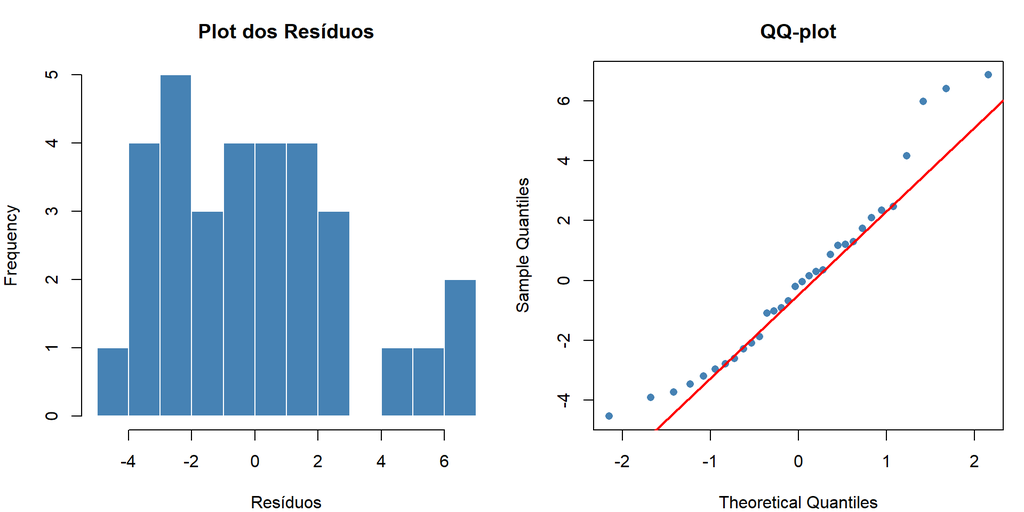

```r
par(mfrow = c(1, 2), mar = c(4, 4, 3, 1))

hist(res1,
     breaks = 10,
     main   = "Plot dos Resíduos",
     xlab   = "Resíduos",
     col    = "steelblue",
     border = "white")

qqnorm(res1, main = "QQ-plot", pch = 16, col = "steelblue")
qqline(res1, col = "red", lwd = 2)
```

Neste modelo, os resíduos parecem aproximadamente normais. O histograma é razoavelmente simétrico, os pontos do QQ-plot ficam próximos da linha.

## Teste de Shapiro-Wilk

O teste de Shapiro-Wilk avalia as seguintes hipóteses:

$$H_0: \text{os resíduos seguem distribuição normal}$$

$$H_1: \text{os resíduos não seguem distribuição normal}$$

```r
shapiro.test(res1)
```

```
    Shapiro-Wilk normality test

data:  res1
W = 0.94508, p-value = 0.1044
```

Quando o p-valor do teste de Shapiro-Wilk não é pequeno e os pontos do QQ-plot estão próximos da linha de referência, não há forte evidência contra a normalidade dos resíduos. Logo, não rejeita a hipótese nula ($H_0$).

Neste caso, o modelo `mpg ~ wt` é útil como exemplo de um diagnóstico visual relativamente adequado.

## Ato 2 - Olhando os dados brutos de ozônio

Agora será usado o banco `airquality`, que contém dados diários de qualidade do ar em Nova York em 1973. A variável de interesse é `Ozone`, que representa a concentração de ozônio em partes por bilhão (ppb).

Aqui não tem modelo, estamos olhando a distribuição bruta da variável resposta (ozônio).

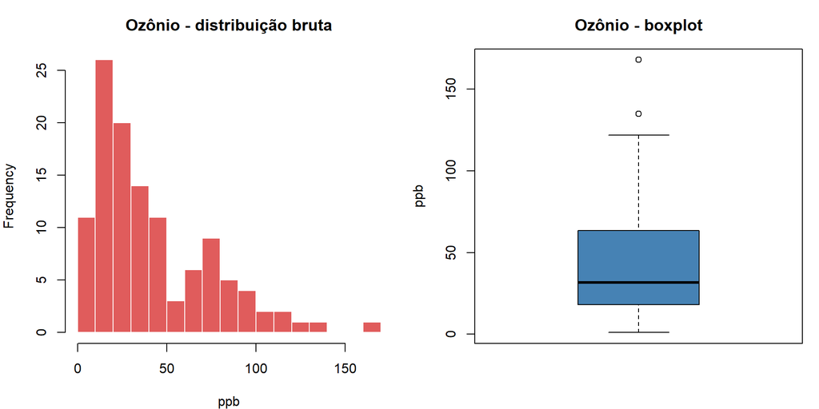

```r
# Entender os dados brutos
dados_ozonio = na.omit(airquality$Ozone)

par(mfrow = c(1, 2), mar = c(4, 4, 3, 1))

hist(dados_ozonio,
     breaks = 12,
     main   = "Ozônio - distribuição bruta",
     xlab   = "ppb",
     col    = "#e05c5c",
     border = "white")

boxplot(dados_ozonio,
        main = "Ozônio - boxplot",
        col  = "steelblue",
        ylab = "ppb")
```

O histograma apresenta assimetria positiva (ou à direita), ou seja, caracteriza-se por ter a cauda mais longa estendendo-se para o lado direito, onde estão os valores maiores. O boxplot indica a presença de valores altos.

Antes de remover ou transformar dados, é importante verificar se esses valores fazem sentido no contexto do problema.

```r
max(dados_ozonio) # 168 ppb
```

```
[1] 168
```

```r
which(dados_ozonio == max(dados_ozonio))  # posição 82
```

```
[1] 82
```

```r
airquality[airquality$Ozone == max(dados_ozonio) &
             !is.na(airquality$Ozone), ]
```

```
    Ozone Solar.R Wind Temp Month Day
117   168     238  3.4   81     8  25
```

**Resultado**: Dia 25/08/1973: 81°F, vento 3.4 mph, sol forte

Em dia quente + sem vento + muito sol = acúmulo de ozônio. Portanto, o valor não é erro de medição, é um evento real.

**O maior valor observado de ozônio não deve ser tratado automaticamente como erro**. Ele pode representar um evento ambiental real, associado a condições como temperatura elevada, baixa velocidade do vento e alta radiação solar. Esse ponto é importante porque, em **diagnóstico de modelos**, a primeira etapa não deve ser corrigir mecanicamente o problema, mas investigar sua causa.

## Ato 3 - Modelo sem transformação

Após a análise inicial da distribuição bruta da variável `Ozone`, foi ajustado um modelo linear para explicar a concentração de ozônio a partir de variáveis meteorológicas presentes no banco airquality. O modelo utilizado foi:

$$Ozone_i = \beta_0 + \beta_1 Solar.R_i + \beta_2 Wind_i + \beta_3 Temp_i + \varepsilon_i$$

em que:

- `Solar.R`: radiação solar;
- `Wind`: velocidade do vento;
- `Temp`: temperatura.

```r
dados_air = na.omit(airquality[, c("Ozone", "Solar.R", "Wind", "Temp")])

modelo2 = lm(Ozone ~ Solar.R + Wind + Temp, data = dados_air)
res2 = residuals(modelo2)

summary(modelo2)
```

```
Call:
lm(formula = Ozone ~ Solar.R + Wind + Temp, data = dados_air)

Residuals:
    Min      1Q  Median      3Q     Max
-40.485 -14.219  -3.551  10.097  95.619

Coefficients:
             Estimate Std. Error t value Pr(>|t|)
(Intercept) -64.34208   23.05472  -2.791  0.00623 **
Solar.R       0.05982    0.02319   2.580  0.01124 *
Wind         -3.33359    0.65441  -5.094 1.52e-06 ***
Temp          1.65209    0.25353   6.516 2.42e-09 ***
---
Signif. codes:  0 '***' 0.001 '**' 0.01 '*' 0.05 '.' 0.1 ' ' 1

Residual standard error: 21.18 on 107 degrees of freedom
Multiple R-squared:  0.6059,    Adjusted R-squared:  0.5948
F-statistic: 54.83 on 3 and 107 DF,  p-value: < 2.2e-16
```

Os resultados indicaram que as três variáveis explicativas foram estatisticamente significativas. A variável `Solar.R` apresentou coeficiente positivo, indicando que maiores valores de radiação solar tendem a estar associados ao aumento da concentração de ozônio. A variável `Temp` também apresentou coeficiente positivo, sugerindo que temperaturas mais altas estão associadas a maiores níveis de ozônio. Por outro lado, `Wind` apresentou coeficiente negativo, indicando que maiores velocidades do vento tendem a reduzir a concentração de ozônio, possivelmente pela dispersão dos poluentes.

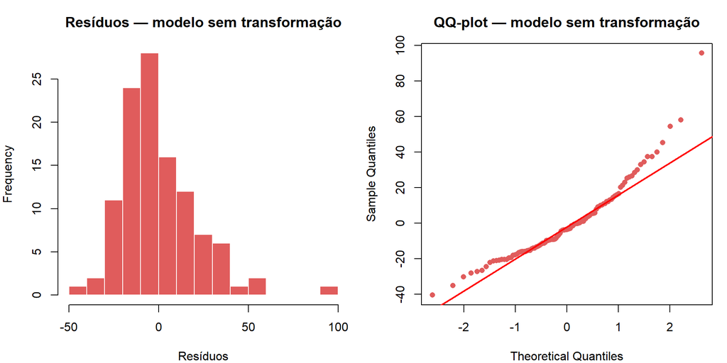

```r
# Diagnóstico da normalidade dos resíduos
par(mfrow = c(1, 2), mar = c(4, 4, 3, 1))

hist(res2,
     breaks = 12,
     main   = "Resíduos — modelo sem transformação",
     xlab   = "Resíduos",
     col    = "#e05c5c",
     border = "white")

qqnorm(res2, main = "QQ-plot — modelo sem transformação",
       pch = 16, col = "#e05c5c")
qqline(res2, col = "red", lwd = 2)
```

No entanto, ao avaliar os resíduos, observou-se que a **suposição de normalidade não foi bem atendida**. O histograma dos resíduos apresentou assimetria, com presença de valores extremos positivos. Além disso, no QQ-plot, os pontos se afastaram da linha de referência principalmente na cauda superior, indicando que os resíduos não seguem bem uma distribuição normal.

```r
shapiro.test(res2)
```

```
    Shapiro-Wilk normality test

data:  res2
W = 0.91709, p-value = 3.618e-06
```

O teste de Shapiro-Wilk confirmou essa evidência. Como o p-valor é muito menor que 0.05, rejeita-se a hipótese nula de normalidade dos resíduos.

Assim, mesmo utilizando variáveis meteorológicas com interpretação física direta, o modelo sem transformação ainda apresentou resíduos com forte desvio da normalidade. Isso sugere que a escala original da variável `Ozone` pode não ser a mais adequada para um modelo linear com erros normalmente distribuídos.

## Ato 4 - Transformação logarítmica da resposta

Como a variável `Ozone` é positiva, assimétrica à direita e apresenta valores altos, foi ajustado um segundo modelo utilizando a transformação logarítmica da resposta. O modelo passou a ser:

$$log(Ozone_i) = \beta_0 + \beta_1 Solar.R_i + \beta_2 Wind_i + \beta_3 Temp_i + \varepsilon_i$$
A transformação logarítmica tem como objetivo reduzir o peso relativo dos valores muito altos, sem removê-los do conjunto de dados. Assim, ela pode ajudar a **diminuir a assimetria da resposta** e melhorar o **comportamento dos resíduos**.

```r
modelo3 = lm(log(Ozone) ~ Solar.R + Wind + Temp, data = dados_air)
res3 = residuals(modelo3)

summary(modelo3)
```

```
Call:
lm(formula = log(Ozone) ~ Solar.R + Wind + Temp, data = dados_air)

Residuals:
     Min       1Q   Median       3Q      Max
-2.06193 -0.29970 -0.00231  0.30756  1.23578

Coefficients:
              Estimate Std. Error t value Pr(>|t|)
(Intercept) -0.2621323  0.5535669  -0.474 0.636798
Solar.R      0.0025152  0.0005567   4.518 1.62e-05 ***
Wind        -0.0615625  0.0157130  -3.918 0.000158 ***
Temp         0.0491711  0.0060875   8.077 1.07e-12 ***
---
Signif. codes:  0 '***' 0.001 '**' 0.01 '*' 0.05 '.' 0.1 ' ' 1

Residual standard error: 0.5086 on 107 degrees of freedom
Multiple R-squared:  0.6644,    Adjusted R-squared:  0.655
F-statistic: 70.62 on 3 and 107 DF,  p-value: < 2.2e-16
```

No modelo com `log(Ozone)`, as variáveis `Solar.R`, `Wind` e `Temp` continuaram estatisticamente significativas. A radiação solar e a temperatura apresentaram efeitos positivos sobre o logaritmo da concentração de ozônio, enquanto a velocidade do vento apresentou efeito negativo.

Além disso, o modelo com transformação apresentou $R^2$ maior que o valor observado no modelo sem transformação. Isso indica que aproximadamente 66,4% da variação em log(Ozone) foi explicada pelas variáveis meteorológicas consideradas.

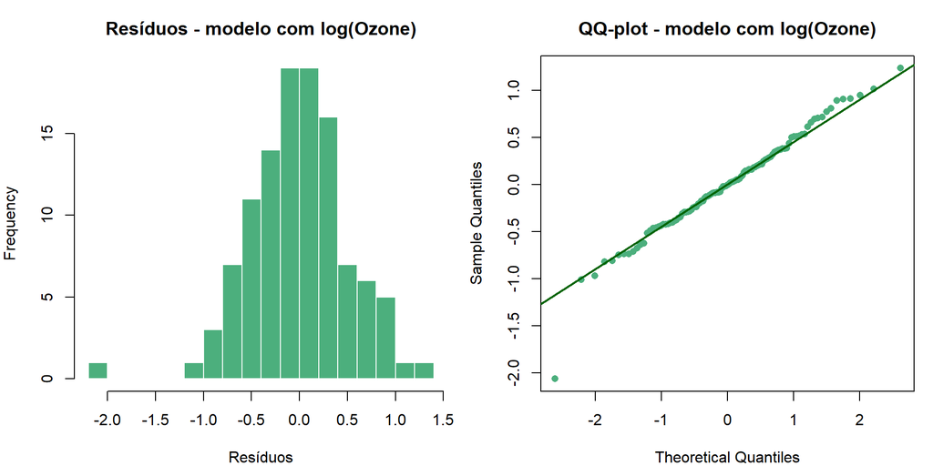

```r
# Diagnóstico dos resíduos após transformação
par(mfrow = c(1, 2), mar = c(4, 4, 3, 1))

hist(res3,
     breaks = 12,
     main   = "Resíduos - modelo com log(Ozone)",
     xlab   = "Resíduos",
     col    = "#4caf7d",
     border = "white")

qqnorm(res3, main = "QQ-plot - modelo com log(Ozone)",
       pch = 16, col = "#4caf7d")
qqline(res3, col = "darkgreen", lwd = 2)
```

O diagnóstico dos resíduos também melhorou. O histograma dos resíduos ficou mais simétrico e concentrado ao redor de zero. No QQ-plot, os pontos ficaram muito mais próximos da linha de referência, indicando maior compatibilidade com a distribuição normal.

```r
shapiro.test(res3)
```

```
    Shapiro-Wilk normality test

data:  res3
W = 0.97749, p-value = 0.05726
```

O teste de Shapiro-Wilk apresentou W = 0.97749 e p = 0.05726. Como o p-valor foi maior que 0.05, não rejeitamos a hipótese nula de normalidade dos resíduos ao nível de 5%.

Portanto, a **transformação logarítmica melhorou substancialmente o comportamento dos resíduos**. Isso não significa que a normalidade foi “provada”, mas indica que, após a transformação, não há evidência estatística forte contra a suposição de normalidade.

## Ato 5 - Comparação visual: modelo sem transformação vs modelo com transformação log

A comparação visual entre os dois modelos mostra claramente o efeito da transformação logarítmica sobre os resíduos.

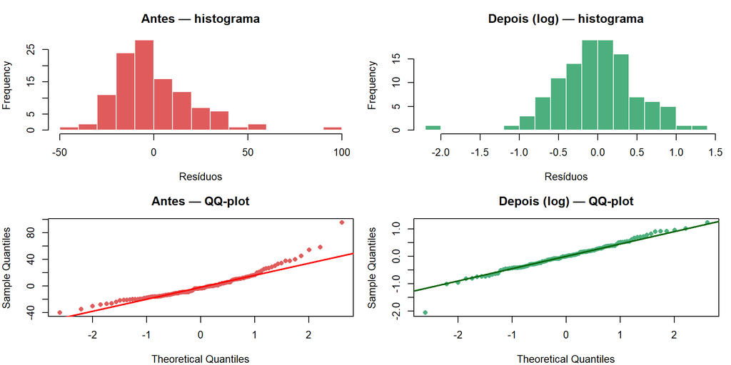

```r
par(mfrow = c(2, 2), mar = c(4, 4, 3, 1))

hist(res2,
     breaks = 12,
     main   = "Antes — histograma",
     xlab   = "Resíduos",
     col    = "#e05c5c",
     border = "white")

hist(res3,
     breaks = 12,
     main   = "Depois (log) — histograma",
     xlab   = "Resíduos",
     col    = "#4caf7d",
     border = "white")

qqnorm(res2, main = "Antes — QQ-plot", pch = 16, col = "#e05c5c")
qqline(res2, col = "red", lwd = 2)

qqnorm(res3, main = "Depois (log) — QQ-plot", pch = 16, col = "#4caf7d")
qqline(res3, col = "darkgreen", lwd = 2)
```

No **modelo sem transformação**, o histograma dos resíduos apresentou assimetria à direita e presença de valores extremos. O QQ-plot também mostrou afastamento dos pontos em relação à linha de referência, principalmente na cauda superior. Esse padrão indica que os resíduos do modelo original não se comportavam bem como uma distribuição normal.

Após a **transformação logarítmica da variável** Ozone, o comportamento dos resíduos melhorou. O histograma ficou mais simétrico e mais concentrado em torno de zero. Além disso, o QQ-plot passou a apresentar pontos mais próximos da linha de referência, indicando melhor aproximação à normalidade.

Dessa forma, a transformação logarítmica reduziu a assimetria e o impacto dos valores extremos, **tornando os resíduos mais compatíveis com a suposição de normalidade**. A comparação reforça que a decisão não deve ser baseada apenas no teste formal, mas também na avaliação visual dos resíduos e no sentido estatístico da transformação.

## Conclusão

Neste exemplo, a normalidade dos resíduos foi avaliada a partir de uma sequência de diagnóstico:

$$\text{Ajustar o modelo} \rightarrow \text{avaliar resíduos} \rightarrow \text{interpretar desvios} \rightarrow \text{decidir uma estratégia}$$

Quando a normalidade não é atendida, o caminho mais adequado é investigar a causa do problema e, se necessário, considerar alternativas como transformações, modelos lineares generalizados, métodos robustos ou bootstrap.